# Problem Statement

Lenders need to know if someone or a company is likely to repay a loan or not before giving it to them. To do this, we want to create a Machine Learning model that can predict this with a high level of accuracy. It's like a yes-or-no question: Will the borrower pay back the loan or not?

```python
#https://www.kaggle.com/datasets/mirzahasnine/loan-data-set
```

```python
#note before running the notebook on Collab please load the train and test datasets
# https://plainenglish.io/blog/how-can-we-upload-data-to-google-colab-ef31394b004a
```

### Data Description

The dataset has 12 columns. It has 11 features to be used predicting the label which is Status columns in the dataset.

### Import Libraries

We will be requiring below libraries

- 1-pandas for data analysis.
- 2-NumPy for numerical operations.
- 3-Matplotlib / seaborn for plotting or data visualization.
- 4-Scikit-Learn for machine learning modelling and evaluation.

```python
# Regular EDA (exploratory data analysis) and plotting libraries
import numpy as np
import pandas as pd
import matplotlib.pyplot as plt
%matplotlib inline
import seaborn as sns
sns.set(style="ticks")

# Preprocessing the data
from sklearn.preprocessing import StandardScaler
from sklearn.preprocessing import OrdinalEncoder, LabelEncoder

# Linear Models from Scikit-Learn
from sklearn.linear_model import LogisticRegression
from sklearn.discriminant_analysis import LinearDiscriminantAnalysis

# Non-linear Models from Scikit-Learn
from sklearn.tree import DecisionTreeClassifier
from sklearn.neighbors import KNeighborsClassifier
from sklearn.svm import SVC
from sklearn.naive_bayes import GaussianNB

# Ensemble Models from Scikit-Learn
from sklearn.ensemble import RandomForestClassifier
from sklearn.ensemble import AdaBoostClassifier
from sklearn.ensemble import GradientBoostingClassifier

# Model Evaluation
from sklearn.model_selection import train_test_split, cross_val_score
from sklearn.model_selection import StratifiedKFold, GridSearchCV
from sklearn.metrics import classification_report, confusion_matrix
from sklearn.metrics import accuracy_score, roc_auc_score, roc_curve
from sklearn.metrics import RocCurveDisplay, auc
```

```python
#Importing the dataset
df_train = pd.read_csv("loan_train.csv")
df_test = pd.read_csv("loan_test.csv")
print(df_train.shape, df_test.shape) # number of rows and columns
```

```
(614, 12) (367, 11)
```

```python
df_train.info()
```

```
<class 'pandas.core.frame.DataFrame'>
RangeIndex: 614 entries, 0 to 613
Data columns (total 12 columns):
 #   Column              Non-Null Count  Dtype
---  ------              --------------  -----
 0   Gender              601 non-null    object
 1   Married             611 non-null    object
 2   Dependents          599 non-null    object
 3   Education           614 non-null    object
 4   Self_Employed       582 non-null    object
 5   Applicant_Income    614 non-null    int64
 6   Coapplicant_Income  614 non-null    float64
 7   Loan_Amount         614 non-null    int64
 8   Term                600 non-null    float64
 9   Credit_History      564 non-null    float64
 10  Area                614 non-null    object
 11  Status              614 non-null    object
dtypes: float64(3), int64(2), object(7)
memory usage: 57.7+ KB
```

```python
df_train.describe()
```

|  | Applicant_Income | Coapplicant_Income | Loan_Amount | Term | Credit_History |
| --- | --- | --- | --- | --- | --- |
| count | 6.140000e+02 | 6.140000e+02 | 6.140000e+02 | 600.00000 | 564.000000 |
| mean | 5.403459e+05 | 1.621246e+05 | 1.414104e+07 | 342.00000 | 0.842199 |
| std | 6.109042e+05 | 2.926248e+05 | 8.815682e+06 | 65.12041 | 0.364878 |
| min | 1.500000e+04 | 0.000000e+00 | 0.000000e+00 | 12.00000 | 0.000000 |
| 25% | 2.877500e+05 | 0.000000e+00 | 9.800000e+06 | 360.00000 | 1.000000 |
| 50% | 3.812500e+05 | 1.188500e+05 | 1.250000e+07 | 360.00000 | 1.000000 |
| 75% | 5.795000e+05 | 2.297250e+05 | 1.647500e+07 | 360.00000 | 1.000000 |
| max | 8.100000e+06 | 4.166700e+06 | 7.000000e+07 | 480.00000 | 1.000000 |

```python
df_train.head()
```

|  | Gender | Married | Dependents | Education | Self_Employed | Applicant_Income | Coapplicant_Income | Loan_Amount | Term | Credit_History | Area | Status |
| --- | --- | --- | --- | --- | --- | --- | --- | --- | --- | --- | --- | --- |
| 0 | Male | No | 0 | Graduate | No | 584900 | 0.0 | 15000000 | 360.0 | 1.0 | Urban | Y |
| 1 | Male | Yes | 1 | Graduate | No | 458300 | 150800.0 | 12800000 | 360.0 | 1.0 | Rural | N |
| 2 | Male | Yes | 0 | Graduate | Yes | 300000 | 0.0 | 6600000 | 360.0 | 1.0 | Urban | Y |
| 3 | Male | Yes | 0 | Not Graduate | No | 258300 | 235800.0 | 12000000 | 360.0 | 1.0 | Urban | Y |
| 4 | Male | No | 0 | Graduate | No | 600000 | 0.0 | 14100000 | 360.0 | 1.0 | Urban | Y |

```python
df_test.head()
```

|  | Gender | Married | Dependents | Education | Self_Employed | Applicant_Income | Coapplicant_Income | Loan_Amount | Term | Credit_History | Area |
| --- | --- | --- | --- | --- | --- | --- | --- | --- | --- | --- | --- |
| 0 | Male | Yes | 0 | Graduate | No | 572000 | 0 | 11000000 | 360.0 | 1.0 | Urban |
| 1 | Male | Yes | 1 | Graduate | No | 307600 | 150000 | 12600000 | 360.0 | 1.0 | Urban |
| 2 | Male | Yes | 2 | Graduate | No | 500000 | 180000 | 20800000 | 360.0 | 1.0 | Urban |
| 3 | Male | Yes | 2 | Graduate | No | 234000 | 254600 | 10000000 | 360.0 | NaN | Urban |
| 4 | Male | No | 0 | Not Graduate | No | 327600 | 0 | 7800000 | 360.0 | 1.0 | Urban |

### Exploratory Data Analysis - EDA)

```python
df_train.dtypes
#To check the data Types
```

```
Gender                 object
Married                object
Dependents             object
Education              object
Self_Employed          object
Applicant_Income        int64
Coapplicant_Income    float64
Loan_Amount             int64
Term                  float64
Credit_History        float64
Area                   object
Status                 object
dtype: object
```

###### note Credit history is float and should contain categorical values not float.

```python
# Updating the data type of Credit_History column as mentioned above
df_train['Credit_History'] = df_train['Credit_History'].astype('object')
df_train.info()
```

```
<class 'pandas.core.frame.DataFrame'>
RangeIndex: 614 entries, 0 to 613
Data columns (total 12 columns):
 #   Column              Non-Null Count  Dtype
---  ------              --------------  -----
 0   Gender              601 non-null    object
 1   Married             611 non-null    object
 2   Dependents          599 non-null    object
 3   Education           614 non-null    object
 4   Self_Employed       582 non-null    object
 5   Applicant_Income    614 non-null    int64
 6   Coapplicant_Income  614 non-null    float64
 7   Loan_Amount         614 non-null    int64
 8   Term                600 non-null    float64
 9   Credit_History      564 non-null    object
 10  Area                614 non-null    object
 11  Status              614 non-null    object
dtypes: float64(2), int64(2), object(8)
memory usage: 57.7+ KB
```

```python
#note the Credit_History is changed into the object
```

```python
#checking null values
df_train.isna().sum()
```

```
Gender                13
Married                3
Dependents            15
Education              0
Self_Employed         32
Applicant_Income       0
Coapplicant_Income     0
Loan_Amount            0
Term                  14
Credit_History        50
Area                   0
Status                 0
dtype: int64
```

```python
df_train['Status'].value_counts()
```

```
Y    422
N    192
Name: Status, dtype: int64
```

```python
count = len(df_train['Status'])
count_y = df_train['Status'].value_counts()['Y']
count_n = df_train['Status'].value_counts()['N']

print('Y:', count_y, f'{(count_y / count) * 100:.2f}%')
print('N:', count_n, f'{(count_n / count) * 100:.2f}%')
#The code generates a summary of the 'Status' column in the DataFrame df_train. The summary includes the following information:
# Total count: It calculates the total number of records in the 'Status' column and assigns it to the variable count.
# Count and percentage of 'Y': It counts the occurrences of 'Y' in the 'Status' column and assigns the count to the variable count_y. It then calculates the percentage of 'Y' by dividing count_y by the total count (count), multiplying by 100, and formatting the result with two decimal places. This information is printed as "Y: count_y percentage_Y%" using the print statement.
# Count and percentage of 'N': It counts the occurrences of 'N' in the 'Status' column and assigns the count to the variable count_n. It calculates the percentage of 'N' by dividing count_n by the total count (count), multiplying by 100, and formatting the result with two decimal places. This information is printed as "N: count_n percentage_N%" using the print statement.
# The summary provides insights into the distribution of 'Y' and 'N' values in the 'Status' column, displaying their respective counts and percentages
```

```
Y: 422 68.73%
N: 192 31.27%
```

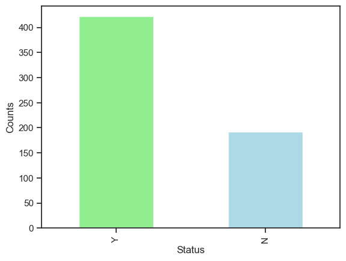

```python
#now plotting above in bar graph
df_train['Status'].value_counts().plot(kind='bar', color=['lightgreen', 'lightblue'])
plt.xlabel('Status')
plt.ylabel('Counts')
plt.show()
```

###### Categorical Variables EDA

###### Gender

```python
categorical_features = []
numerical_features = []
for i in df_train.drop('Status', axis=1).columns:
    if df_train[i].dtype == 'O':
        categorical_features.append(i)
    else:
        numerical_features.append(i)
print(categorical_features)
print(numerical_features)
#Note we have printed numerical and categorical variables
```

```
['Gender', 'Married', 'Dependents', 'Education', 'Self_Employed', 'Credit_History', 'Area']
['Applicant_Income', 'Coapplicant_Income', 'Loan_Amount', 'Term']
```

```python
df_train.Gender.value_counts(dropna = False)
```

```
Male      489
Female    112
NaN        13
Name: Gender, dtype: int64
```

```python
df_train.Gender.value_counts()
```

```
Male      489
Female    112
Name: Gender, dtype: int64
```

###### Pie chart Plotting

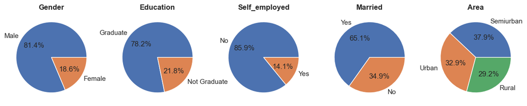

```python
fig, ax = plt.subplots(1, 5, figsize=(15, 10))
#creates a figure with one row and four columns of subplots, resulting in four subplots arranged horizontally.
#The figsize parameter specifies the size of the figure.
features = ['Gender', 'Education', 'Self_Employed', 'Married','Area']
# list contains the names of the categorical features: 'Gender', 'Education', 'Self_Employed', and 'Married'.
#These features will be displayed as pie charts in the subplots.

for i, feature in enumerate(features):
#The for loop iterates over each element (feature) in the features list, along with an index (i) indicating the position of the feature in the list.
    pie_data = df_train[feature].value_counts() #calculates the frequency of each unique value in the column.
    pie_data.plot.pie(ax=ax[i], autopct='%1.1f%%')
    ax[i].set_ylabel('') #removes the y-axis label for the current subplot.
    ax[i].set_title(feature.capitalize(), fontweight='bold')# sets the title for the current subplot, capitalizing the feature name and making the title bold.

plt.subplots_adjust(hspace=0.5)#adjusts the vertical spacing between subplots to provide some spacing.
plt.show()

#The code creates a figure with four subplots, each showing a pie chart for a specific categorical feature.
#It iterates over the features, generates the value counts, plots the pie chart, sets titles and labels, and displays the figure.
```

###### Checking relation between Number of Dependents and Area

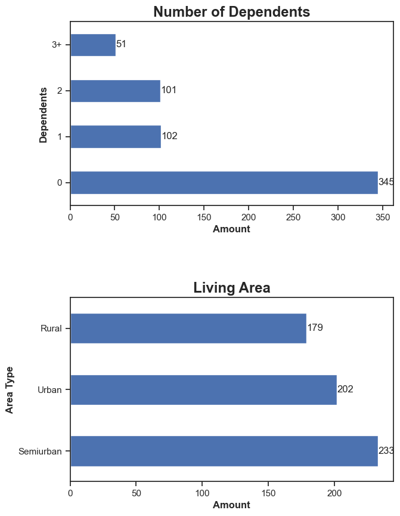

```python
fig, axes = plt.subplots(2, 1, figsize=(7, 10))

dependents_bar = df_train['Dependents'].value_counts()
area_bar = df_train['Area'].value_counts()

dependents_bar.plot.barh(ax=axes[0])
area_bar.plot.barh(ax=axes[1])

plt.subplots_adjust(hspace=0.5)

for ax in axes:
    ax.bar_label(ax.containers[0])
    ax.set_xlabel('Amount', fontweight='bold')
    ax.set_ylabel('Dependents' if ax == axes[0] else 'Area Type', fontweight='bold')

axes[0].set_title('Number of Dependents', fontweight='bold', fontsize='x-large')
axes[1].set_title('Living Area', fontweight='bold', fontsize='x-large')

plt.show()
#this code creates a figure with two subplots and plots horizontal bar charts for the 'Dependents' and 'Area' columns of a DataFrame.
#It also adds labels, titles, and adjusts the spacing between the subplots for better visualization.
```

```python
df_train.info()
```

```
<class 'pandas.core.frame.DataFrame'>
RangeIndex: 614 entries, 0 to 613
Data columns (total 12 columns):
 #   Column              Non-Null Count  Dtype
---  ------              --------------  -----
 0   Gender              601 non-null    object
 1   Married             611 non-null    object
 2   Dependents          599 non-null    object
 3   Education           614 non-null    object
 4   Self_Employed       582 non-null    object
 5   Applicant_Income    614 non-null    int64
 6   Coapplicant_Income  614 non-null    float64
 7   Loan_Amount         614 non-null    int64
 8   Term                600 non-null    float64
 9   Credit_History      564 non-null    object
 10  Area                614 non-null    object
 11  Status              614 non-null    object
dtypes: float64(2), int64(2), object(8)
memory usage: 57.7+ KB
```

```python
#Note:The majority of people in this dataset has 0 dependents which is 345
#The living area are almost evenly distributed between Rural, Urban & Semiurban.
```